# Data pipelines on the cloud

## ETL (extract - transform - load) se vrlo često miješa s pojmom data pipelinea

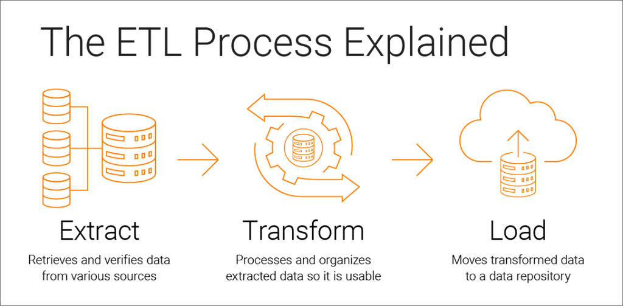

## ETL se vrlo često povezuje s data warehousingom te BI (business inteligence)

## Data pipelines su širi pojam, mogu obuhvaćati u sebi ETL

### Koraci:

### 1.) Data ingestion - obuhvat podataka iz različitih izvora

### 2.) Data cleaning - čišćenje podataka od različitih grešaka

### 3.) Data transformation - pretvaranje podataka u odgovarući format

### Ovo su dosad koraci ETL-a

### 4.) Data analysis - primjena različitih statističkih ili ML metoda kako bi se otkrile važne informacije u tim podacima

### 5.) Data visualisation - vizualizacija podataka u razumljivom formatu (grafikoni)

## dodatna značajka data pipelinea = real time processing

### Amazon, Alibaba, Njuškalo, Zaba, Podravka trebaju rezultate obrade u realnom vremenu, a ne tek za par mjeseci

# Top 5 Cloud Services za Data Science Pipelines

### 1.) Amazon web services (AWS)

### 2.) Google Cloud Platform (GCP)

### 3.) Microsoft Azure

### 4.) IBM Cloud

### 5.) Alibaba Cloud

# **Zadatak 1** - kako odabrati koju tehnologiju / platformu naučiti koristiti?

# Izrada data pipelinea korištenjem AWS-a

## Razumijevanje Komponenti

### Prije nego što se upustimo u proces, važno je razumjeti ključne AWS usluge koje se često koriste u podatkovnim cjevovodima:

- S3: Objektna pohrana za pohranu podataka.
- Kinesis: Usluga za streaming podataka u stvarnom vremenu.
- Lambda: Serverless usluga za pokretanje koda.
- Glue: ETL usluga za transformaciju podataka.
- Athena: Interaktivna usluga za upite podataka pohranjenih na S3.
- EMR: Upravljana Hadoop i Spark usluga za obradu velikih podataka.

# Uobičajene faze pri izradi data pipelinea (onih 5 gore) i odgovarajući AWS Alati

## Prikupljanje Podataka

- Alati: S3, Kinesis, Lambda
- Proces: Podaci se prikupljaju iz različitih izvora (npr. baze podataka, API-jevi, IoT uređaji) i pohranjuju na S3 ili streamaju u Kinesis. Lambda funkcije mogu pokrenuti događaje za unos podataka.

## Transformacija Podataka

- Alati: Glue, Lambda, EMR
- Proces: Podaci se čiste, normaliziraju i transformiraju u format prikladan za analizu. Glue se koristi za ETL zadatke, dok se Lambda ili EMR mogu koristiti za složenije transformacije.

## Pohrana Podataka

- Alati: S3
- Proces: Transformirani podaci pohranjuju se na S3 za daljnju obradu ili analizu.

## Analiza Podataka

- Alati: Athena, EMR
- Proces: Podaci se analiziraju korištenjem SQL upita (Athena) ili okvira za velike podatke poput Spark-a (EMR).

## Vizualizacija Podataka

- Alati: QuickSight, Tableau
- Proces: Uvidi iz podataka vizualiziraju se korištenjem alata za vizualizaciju podataka.

## Jezici i Vještine - Iako AWS usluge često nude sučelja koja smanjuju potrebu za direktnim programiranjem, znanje sljedećih jezika i vještina može biti korisno:

- Python: Široko korišten za obradu i analizu podataka.
- SQL: Za upite podataka u Atheni ili drugim bazama podataka.
- Shell skripte: Za automatizaciju zadataka i upravljanje cjevovodima.
- AWS CLI: Za interakciju s AWS uslugama iz naredbenog retka.
- CloudFormation: Za definiranje i upravljanje AWS resursima kao kodom.

## Primjer Data pipelinea: Obrada IoT Podataka u Stvarnom Vremenu

- IoT uređaji generiraju podatke senzora i šalju ih u Kinesis.
- Lambda funkcije obrađuju Kinesis stream, filtrirajući i transformirajući podatke.
- Transformirani podaci pohranjuju se na S3.
- Athena se koristi za upite podataka i generiranje analitike u stvarnom vremenu.
- Rezultati se vizualiziraju u QuickSightu.

## Primjer Data Pipelinea - kreiranje Data Warehousea i analiza podataka o prodaji

- Data extraction: Glue / Lamda - kreiranje funkcija za učitavanje podataka iz csv fileova
- Data transformation: Korištenjem Glue alata se podaci čiste i transformiraju (missing values, normalizacija podataka)
- Data loading: Učitavanje podataka u S3
- Data querying: korištenje Athene za postavljanje upita i izradu reporta

### Create a SageMaker session

sagemaker_session = boto3.session.Session()

### Define the training job

- training_job_name = 'customer-churn-model'
- algorithm_name = 'xgboost' # Replace with your desired algorithm
- role_arn = 'your_role_arn' # Replace with your IAM role ARN

### Deploy the model as an endpoint

- predictor = training_job.deploy(
  - instance_type='ml.m4.xlarge',
  - initial_instance_count=1 )